# Employee Attrition

Jon Gomez (jag2j), Michael Langmayr, Nathan England, and Yihnew Eshetu

# About the data

We will analyze the “IBM HR Analytics Employee Attrition & Performance” dataset ((link)[https://www.kaggle.com/pavansubhasht/ibm-hr-analytics-attrition-dataset]). The dataset documentation says that it was synthesized by data scientists at IBM. Observations describe hypothetical employees. Rows measure the employee retention status, metrics about the workplace, and details about the employee.

# Preparation

## Libraries

```r
suppressPackageStartupMessages(library(tidyverse))
suppressPackageStartupMessages(library(leaps))     # model selection tools
suppressPackageStartupMessages(library(faraway))   # VIF function

source('./lib/fmrhs.R') # requires tidyverse
source('./lib/Pretty correlation.R')
```

## Loading the data

We load the data using a custom column mapping. A few considerations apply:

- Several columns are are originally numeric levels. We recode these from the data description.
- A few columns are irrelevant or constant across the data. We drop these.

```r
# column mappings
types = cols(
  # continuous variables
  Age = col_double(),              DailyRate = col_double(),
  DistanceFromHome = col_double(), HourlyRate = col_double(),
  JobLevel = col_factor(1:5),

  # ordered factors we later recode
  #   e.g., JobSatisfaction ranges from 1 - 4 (= 'Low' to 'Very High')
  Education                = col_factor(levels = 1:5),
  EnvironmentSatisfaction  = col_factor(1:4),
  JobInvolvement           = col_factor(1:4),
  JobSatisfaction          = col_factor(levels = 1:4),
  PerformanceRating        = col_factor(levels = 1:4),
  RelationshipSatisfaction = col_factor(levels = 1:4),
  WorkLifeBalance          = col_factor(levels = 1:4),

  # other factors
  BusinessTravel =  col_factor(levels = c('Non-Travel', 'Travel_Rarely', 'Travel_Frequently')),
  Gender = col_factor(),            JobRole = col_factor(),
  MaritalStatus = col_factor(),     EducationField = col_factor(),

  # things we have decided to treat as factors
  Department = col_factor(),        # we presume we could map to a taxonomy
  StockOptionLevel = col_factor(),  # unclear scale

  # true/false
  Attrition = col_factor(),
  OverTime = col_factor(),

  # drop
  EmployeeCount = col_skip(),  # always 1
  StandardHours = col_skip(),  # always 40
  EmployeeNumber = col_skip(), # 1, 2, ...
  Over18 = col_skip(),         # always true

  # continous values
  MonthlyIncome = col_double(),       MonthlyRate = col_double(),
  NumCompaniesWorked = col_double(),  PercentSalaryHike = col_double(),
  TotalWorkingYears = col_double(),   TrainingTimesLastYear = col_double(),
  WorkLifeBalance = col_double(),     YearsAtCompany = col_double(),
  YearsInCurrentRole = col_double(),  YearsSinceLastPromotion = col_double(),
  YearsWithCurrManager = col_double()
)

# read in using mapping
ibm = read_csv("data/ibm.csv", col_types = types)

# rename levels
ibm$Education = recode(ibm$Education,
                       '1' = 'Below College', '2' = 'College', '3' = 'Bachelor', '4' = 'Master', '5' = 'Doctor')
ibm$EnvironmentSatisfaction = recode(ibm$EnvironmentSatisfaction,
                       '1' = 'Low', '2' = 'Medium', '3' = 'High', '4' = 'Very High')
ibm$JobInvolvement = recode(ibm$JobInvolvement,
                       '1' = 'Low', '2' = 'Medium', '3' = 'High', '4' = 'Very High')
ibm$JobSatisfaction = recode(ibm$JobSatisfaction,
                       '1' = 'Low', '2' = 'Medium', '3' = 'High', '4' = 'Very High')
ibm$PerformanceRating = recode(ibm$PerformanceRating,
                       '1' = 'Low', '2' = 'Good', '3' = 'Excellent', '4' = 'Outstanding')
ibm$RelationshipSatisfaction = recode(ibm$RelationshipSatisfaction,
                       '1' = 'Low', '2' = 'Medium', '3' = 'High', '4' = 'Very High')
ibm$WorkLifeBalance = recode(ibm$WorkLifeBalance,
                       '1' = 'Bad', '2' = 'Good', '3' = 'Better', '4' = 'Best')

# set contrasts for yes/no levels
ibm$Attrition = relevel(ibm$Attrition, ref = "No")
ibm$OverTime = relevel(ibm$OverTime, ref = "No")
```

## Additional data manipulations

We produce a defactored version of the data for which we have replaced factors with numeric vectors.

```r
ibm.defactored = mutate_if(ibm, is.factor, ~ as.numeric(.x))
```

## Sample observations

We show some sample data:

```r
# a sample observation
t(head(ibm, n = 1))
```

```
                         [,1]
Age                      "41"
Attrition                "Yes"
BusinessTravel           "Travel_Rarely"
DailyRate                "1102"
Department               "Sales"
DistanceFromHome         "1"
Education                "College"
EducationField           "Life Sciences"
EnvironmentSatisfaction  "Medium"
Gender                   "Female"
HourlyRate               "94"
JobInvolvement           "High"
JobLevel                 "2"
JobRole                  "Sales Executive"
JobSatisfaction          "Very High"
MaritalStatus            "Single"
MonthlyIncome            "5993"
MonthlyRate              "19479"
NumCompaniesWorked       "8"
OverTime                 "Yes"
PercentSalaryHike        "11"
PerformanceRating        "Excellent"
RelationshipSatisfaction "Low"
StockOptionLevel         "0"
TotalWorkingYears        "8"
TrainingTimesLastYear    "0"
WorkLifeBalance          "Bad"
YearsAtCompany           "6"
YearsInCurrentRole       "4"
YearsSinceLastPromotion  "0"
YearsWithCurrManager     "5"
```

```r
head(ibm, n = 10)[,c(1:5)]
```

| Age | Attrition | BusinessTravel | DailyRate | Department |
| --- | --- | --- | --- | --- |
| 41 | Yes | Travel_Rarely | 1102 | Sales |
| 49 | No | Travel_Frequently | 279 | Research & Development |
| 37 | Yes | Travel_Rarely | 1373 | Research & Development |
| 33 | No | Travel_Frequently | 1392 | Research & Development |
| 27 | No | Travel_Rarely | 591 | Research & Development |
| 32 | No | Travel_Frequently | 1005 | Research & Development |
| 59 | No | Travel_Rarely | 1324 | Research & Development |
| 30 | No | Travel_Rarely | 1358 | Research & Development |
| 38 | No | Travel_Frequently | 216 | Research & Development |
| 36 | No | Travel_Rarely | 1299 | Research & Development |

# General Observations

There are 1,470 rows and 31 columns.

```r
par(mfrow=c(2,2))
plot(ibm$EducationField)
plot(ibm$JobInvolvement)
```

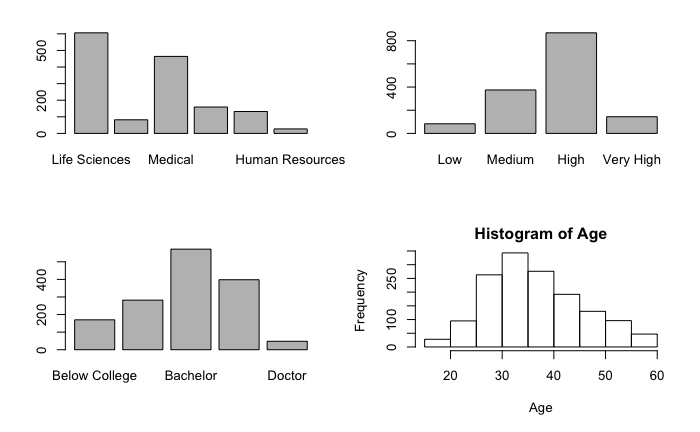

```r
plot(ibm$Education)
with(ibm, hist(Age))
```

```r
summary(ibm)
```

```
      Age        Attrition            BusinessTravel   DailyRate                       Department  DistanceFromHome         Education
 Min.   :18.00   No :1233   Non-Travel       : 150   Min.   : 102.0   Sales                 :446   Min.   : 1.000   Below College:170
 1st Qu.:30.00   Yes: 237   Travel_Rarely    :1043   1st Qu.: 465.0   Research & Development:961   1st Qu.: 2.000   College      :282
 Median :36.00              Travel_Frequently: 277   Median : 802.0   Human Resources       : 63   Median : 7.000   Bachelor     :572
 Mean   :36.92                                       Mean   : 802.5                                Mean   : 9.193   Master       :398
 3rd Qu.:43.00                                       3rd Qu.:1157.0                                3rd Qu.:14.000   Doctor       : 48
 Max.   :60.00                                       Max.   :1499.0                                Max.   :29.000

          EducationField EnvironmentSatisfaction    Gender      HourlyRate       JobInvolvement JobLevel                      JobRole     JobSatisfaction
 Life Sciences   :606    Low      :284           Female:588   Min.   : 30.00   Low      : 83    1:543    Sales Executive          :326   Low      :289
 Other           : 82    Medium   :287           Male  :882   1st Qu.: 48.00   Medium   :375    2:534    Research Scientist       :292   Medium   :280
 Medical         :464    High     :453                        Median : 66.00   High     :868    3:218    Laboratory Technician    :259   High     :442
 Marketing       :159    Very High:446                        Mean   : 65.89   Very High:144    4:106    Manufacturing Director   :145   Very High:459
 Technical Degree:132                                         3rd Qu.: 83.75                    5: 69    Healthcare Representative:131
 Human Resources : 27                                         Max.   :100.00                             Manager                  :102
                                                                                                         (Other)                  :215
  MaritalStatus MonthlyIncome    MonthlyRate    NumCompaniesWorked OverTime   PercentSalaryHike   PerformanceRating RelationshipSatisfaction
 Single  :470   Min.   : 1009   Min.   : 2094   Min.   :0.000      No :1054   Min.   :11.00     Low        :   0    Low      :276
 Married :673   1st Qu.: 2911   1st Qu.: 8047   1st Qu.:1.000      Yes: 416   1st Qu.:12.00     Good       :   0    Medium   :303
 Divorced:327   Median : 4919   Median :14236   Median :2.000                 Median :14.00     Excellent  :1244    High     :459
                Mean   : 6503   Mean   :14313   Mean   :2.693                 Mean   :15.21     Outstanding: 226    Very High:432
                3rd Qu.: 8379   3rd Qu.:20462   3rd Qu.:4.000                 3rd Qu.:18.00
                Max.   :19999   Max.   :26999   Max.   :9.000                 Max.   :25.00

 StockOptionLevel TotalWorkingYears TrainingTimesLastYear WorkLifeBalance YearsAtCompany   YearsInCurrentRole YearsSinceLastPromotion YearsWithCurrManager
 0:631            Min.   : 0.00     Min.   :0.000         Bad   : 80      Min.   : 0.000   Min.   : 0.000     Min.   : 0.000          Min.   : 0.000
 1:596            1st Qu.: 6.00     1st Qu.:2.000         Good  :344      1st Qu.: 3.000   1st Qu.: 2.000     1st Qu.: 0.000          1st Qu.: 2.000
 3: 85            Median :10.00     Median :3.000         Better:893      Median : 5.000   Median : 3.000     Median : 1.000          Median : 3.000
 2:158            Mean   :11.28     Mean   :2.799         Best  :153      Mean   : 7.008   Mean   : 4.229     Mean   : 2.188          Mean   : 4.123
                  3rd Qu.:15.00     3rd Qu.:3.000                         3rd Qu.: 9.000   3rd Qu.: 7.000     3rd Qu.: 3.000          3rd Qu.: 7.000
                  Max.   :40.00     Max.   :6.000                         Max.   :40.000   Max.   :18.000     Max.   :15.000          Max.   :17.000
```

## Correlation

We look at columns for which the correlation is greater than 70 in the defactored data:

```r
p = round(cor(ibm.defactored) * 100)
for(i in 1:nrow(p)) {
  for(j in i:ncol(p)) {
    if(i == j) next
    val = p[i,j]
    if(abs(val) > 70) {
      r = row.names(p)[i]
      c = colnames(p)[j]
      str = paste("cor(", r, ", ", c, ") = ", val, "\n")
      cat(str)
    }
  }
}
```

```
cor( JobLevel ,  MonthlyIncome ) =  95
cor( JobLevel ,  TotalWorkingYears ) =  78
cor( MonthlyIncome ,  TotalWorkingYears ) =  77
cor( PercentSalaryHike ,  PerformanceRating ) =  77
cor( YearsAtCompany ,  YearsInCurrentRole ) =  76
cor( YearsAtCompany ,  YearsWithCurrManager ) =  77
cor( YearsInCurrentRole ,  YearsWithCurrManager ) =  71
```

We also examine the VIFs of the defactored data for general interest. We perform a formal test when we investigate specific models.

```r
model.defactored = lm(MonthlyIncome ~ ., data = ibm.defactored)
model.defactored.vifs = faraway::vif(model.defactored)

# Five highest VIFs with this "defactored" model on Monthly income
#
model.defactored.vifs[order(model.defactored.vifs, decreasing = T)][1:5]
```

```
   TotalWorkingYears       YearsAtCompany             JobLevel YearsWithCurrManager   YearsInCurrentRole
            4.748838             4.611272             2.991802             2.788017             2.740781
```

# Question 1

Our first question is

> What factors correlate with attrition?

```r
library(MASS)
null.model <- glm(Attrition ~ 1, family = "binomial", data = ibm)
full.model <- glm(Attrition ~ ., family = "binomial", data = ibm)
```

```r
#Forward selection model
forward_model <- null.model %>% stepAIC(trace = FALSE, direction = "forward")
summary(forward_model)
```

```
Call:
glm(formula = Attrition ~ 1, family = "binomial", data = ibm)

Deviance Residuals:
   Min      1Q  Median      3Q     Max
-0.593  -0.593  -0.593  -0.593   1.910

Coefficients:
            Estimate Std. Error z value Pr(>|z|)
(Intercept) -1.64915    0.07093  -23.25   <2e-16 ***
---
Signif. codes:  0 ‘***’ 0.001 ‘**’ 0.01 ‘*’ 0.05 ‘.’ 0.1 ‘ ’ 1

(Dispersion parameter for binomial family taken to be 1)

    Null deviance: 1298.6  on 1469  degrees of freedom
Residual deviance: 1298.6  on 1469  degrees of freedom
AIC: 1300.6

Number of Fisher Scoring iterations: 3
```

```r
coef(forward_model)
```

```
(Intercept)
  -1.649145
```

```r
#Backward elimination model
backward_model <- full.model %>% stepAIC(trace = FALSE, direction = "backward")
summary(backward_model)
```

```
Call:
glm(formula = Attrition ~ Age + BusinessTravel + DailyRate +
    DistanceFromHome + EducationField + EnvironmentSatisfaction +
    Gender + JobInvolvement + JobLevel + JobRole + JobSatisfaction +
    NumCompaniesWorked + OverTime + RelationshipSatisfaction +
    StockOptionLevel + TotalWorkingYears + TrainingTimesLastYear +
    WorkLifeBalance + YearsAtCompany + YearsInCurrentRole + YearsSinceLastPromotion +
    YearsWithCurrManager, family = "binomial", data = ibm)

Deviance Residuals:
    Min       1Q   Median       3Q      Max
-1.7553  -0.4417  -0.2032  -0.0633   3.4683

Coefficients:
                                    Estimate Std. Error z value Pr(>|z|)
(Intercept)                        4.3531602  0.9392242   4.635 3.57e-06 ***
Age                               -0.0282390  0.0140546  -2.009 0.044512 *
BusinessTravelTravel_Rarely        1.0724588  0.3972841   2.699 0.006945 **
BusinessTravelTravel_Frequently    2.0982316  0.4332062   4.843 1.28e-06 ***
DailyRate                         -0.0004513  0.0002317  -1.948 0.051462 .
DistanceFromHome                   0.0547174  0.0114721   4.770 1.85e-06 ***
EducationFieldOther                0.0293689  0.4443357   0.066 0.947301
EducationFieldMedical             -0.0404147  0.2294981  -0.176 0.860215
EducationFieldMarketing            0.4913945  0.3366108   1.460 0.144337
EducationFieldTechnical Degree     1.0981947  0.3241962   3.387 0.000705 ***
EducationFieldHuman Resources      0.7387781  0.8042631   0.919 0.358317
EnvironmentSatisfactionMedium     -1.0754392  0.2900961  -3.707 0.000210 ***
EnvironmentSatisfactionHigh       -1.1763190  0.2664673  -4.414 1.01e-05 ***
EnvironmentSatisfactionVery High  -1.3788833  0.2685296  -5.135 2.82e-07 ***
GenderMale                         0.4045242  0.1943798   2.081 0.037425 *
JobInvolvementMedium              -1.2037665  0.3697265  -3.256 0.001131 **
JobInvolvementHigh                -1.5006480  0.3481340  -4.311 1.63e-05 ***
JobInvolvementVery High           -2.1187967  0.4819941  -4.396 1.10e-05 ***
JobLevel2                         -1.6610472  0.4468005  -3.718 0.000201 ***
JobLevel3                         -0.3861767  0.5643118  -0.684 0.493765
JobLevel4                         -1.6316813  0.9884549  -1.651 0.098792 .
JobLevel5                          0.7842021  1.2810048   0.612 0.540420
JobRoleResearch Scientist         -1.6456703  0.5097871  -3.228 0.001246 **
JobRoleLaboratory Technician      -0.5177020  0.4817171  -1.075 0.282508
JobRoleManufacturing Director     -0.8685782  0.4587891  -1.893 0.058332 .
```

[output cut: 20 more lines]

```
WorkLifeBalanceBest               -1.0654284  0.4398874  -2.422 0.015433 *
YearsAtCompany                     0.0980868  0.0427271   2.296 0.021695 *
YearsInCurrentRole                -0.1456140  0.0510833  -2.851 0.004365 **
YearsSinceLastPromotion            0.1653842  0.0453821   3.644 0.000268 ***
YearsWithCurrManager              -0.1433559  0.0504213  -2.843 0.004467 **
---
Signif. codes:  0 ‘***’ 0.001 ‘**’ 0.01 ‘*’ 0.05 ‘.’ 0.1 ‘ ’ 1

(Dispersion parameter for binomial family taken to be 1)

    Null deviance: 1298.58  on 1469  degrees of freedom
Residual deviance:  784.02  on 1420  degrees of freedom
AIC: 884.02

Number of Fisher Scoring iterations: 7
```

```r
coef(backward_model)
```

```
                      (Intercept)                               Age       BusinessTravelTravel_Rarely   BusinessTravelTravel_Frequently
                     4.3531602451                     -0.0282389950                      1.0724587810                      2.0982315917
                        DailyRate                  DistanceFromHome               EducationFieldOther             EducationFieldMedical
                    -0.0004513452                      0.0547174338                      0.0293688761                     -0.0404147266
          EducationFieldMarketing    EducationFieldTechnical Degree     EducationFieldHuman Resources     EnvironmentSatisfactionMedium
                     0.4913945299                      1.0981946981                      0.7387781113                     -1.0754391872
      EnvironmentSatisfactionHigh  EnvironmentSatisfactionVery High                        GenderMale              JobInvolvementMedium
                    -1.1763190106                     -1.3788832853                      0.4045242058                     -1.2037665115
               JobInvolvementHigh           JobInvolvementVery High                         JobLevel2                         JobLevel3
                    -1.5006480095                     -2.1187966592                     -1.6610472097                     -0.3861767395
                        JobLevel4                         JobLevel5         JobRoleResearch Scientist      JobRoleLaboratory Technician
                    -1.6316812837                      0.7842021320                     -1.6456702677                     -0.5177020441
    JobRoleManufacturing Director  JobRoleHealthcare Representative                    JobRoleManager       JobRoleSales Representative
                    -0.8685782388                     -1.3068202189                     -2.3003018378                     -0.0317304782
         JobRoleResearch Director            JobRoleHuman Resources             JobSatisfactionMedium               JobSatisfactionHigh
                    -3.4879960469                     -0.7933815827                     -0.6769504258                     -0.6452929428
         JobSatisfactionVery High                NumCompaniesWorked                       OverTimeYes    RelationshipSatisfactionMedium
                    -1.2878172329                      0.2079536441                      2.1543852202                     -0.9681221969
     RelationshipSatisfactionHigh RelationshipSatisfactionVery High                 StockOptionLevel1                 StockOptionLevel3
                    -0.9888428492                     -0.9838306476                     -1.4831196856                     -0.7873576549
                StockOptionLevel2                 TotalWorkingYears             TrainingTimesLastYear               WorkLifeBalanceGood
                    -1.4574610759                     -0.0682058529                     -0.1871185134                     -0.9524056152
            WorkLifeBalanceBetter               WorkLifeBalanceBest                    YearsAtCompany                YearsInCurrentRole
                    -1.4689607987                     -1.0654283974                      0.0980867603                     -0.1456139605
          YearsSinceLastPromotion              YearsWithCurrManager
                     0.1653841805                     -0.1433558510
```

```r
backward_model$anova
```

```
Stepwise Model Path
Analysis of Deviance Table

Initial Model:
Attrition ~ Age + BusinessTravel + DailyRate + Department + DistanceFromHome +
    Education + EducationField + EnvironmentSatisfaction + Gender +
    HourlyRate + JobInvolvement + JobLevel + JobRole + JobSatisfaction +
    MaritalStatus + MonthlyIncome + MonthlyRate + NumCompaniesWorked +
    OverTime + PercentSalaryHike + PerformanceRating + RelationshipSatisfaction +
    StockOptionLevel + TotalWorkingYears + TrainingTimesLastYear +
    WorkLifeBalance + YearsAtCompany + YearsInCurrentRole + YearsSinceLastPromotion +
    YearsWithCurrManager

Final Model:
Attrition ~ Age + BusinessTravel + DailyRate + DistanceFromHome +
    EducationField + EnvironmentSatisfaction + Gender + JobInvolvement +
    JobLevel + JobRole + JobSatisfaction + NumCompaniesWorked +
    OverTime + RelationshipSatisfaction + StockOptionLevel +
    TotalWorkingYears + TrainingTimesLastYear + WorkLifeBalance +
    YearsAtCompany + YearsInCurrentRole + YearsSinceLastPromotion +
    YearsWithCurrManager

                 Step Df   Deviance Resid. Df Resid. Dev      AIC
1                                        1407   775.2980 901.2980
2         - Education  4 0.80329239      1411   776.1013 894.1013
3 - PerformanceRating  1 0.07792738      1412   776.1792 892.1792
4 - PercentSalaryHike  1 0.19736668      1413   776.3766 890.3766
5        - Department  2 2.28258863      1415   778.6592 888.6592
6     - MaritalStatus  2 2.30986423      1417   780.9690 886.9690
7       - MonthlyRate  1 0.47234427      1418   781.4414 885.4414
8        - HourlyRate  1 0.68629984      1419   782.1277 884.1277
9     - MonthlyIncome  1 1.89642732      1420   784.0241 884.0241
```

```r
#Stepwise regression model using full
step_model <- full.model %>% stepAIC(trace = FALSE, direction = "both")
```

```r
#Check multicollinearity
step_doubles <- step_model$model[, sapply(step_model$model, is.double) ]
faraway::vif(step_doubles)
```

```
                    Age               DailyRate        DistanceFromHome      NumCompaniesWorked       TotalWorkingYears   TrainingTimesLastYear
               1.982299                1.007948                1.002881                1.240876                3.084075                1.007198
         YearsAtCompany      YearsInCurrentRole YearsSinceLastPromotion    YearsWithCurrManager
               4.530921                2.680190                1.665339                2.727770
```

```r
#Stepwise regression model with BIC
bic_model <- full.model %>% stepAIC(trace = FALSE, direction = "both", k = log(nrow(ibm)) )
#summary(step_model)
#coef(step_model)
bic_model$anova
```

```
Stepwise Model Path
Analysis of Deviance Table

Initial Model:
Attrition ~ Age + BusinessTravel + DailyRate + Department + DistanceFromHome +
    Education + EducationField + EnvironmentSatisfaction + Gender +
    HourlyRate + JobInvolvement + JobLevel + JobRole + JobSatisfaction +
    MaritalStatus + MonthlyIncome + MonthlyRate + NumCompaniesWorked +
    OverTime + PercentSalaryHike + PerformanceRating + RelationshipSatisfaction +
    StockOptionLevel + TotalWorkingYears + TrainingTimesLastYear +
    WorkLifeBalance + YearsAtCompany + YearsInCurrentRole + YearsSinceLastPromotion +
    YearsWithCurrManager

Final Model:
Attrition ~ Age + BusinessTravel + Department + DistanceFromHome +
    EnvironmentSatisfaction + JobInvolvement + JobLevel + JobSatisfaction +
    NumCompaniesWorked + OverTime + StockOptionLevel + YearsInCurrentRole +
    YearsSinceLastPromotion

                         Step Df    Deviance Resid. Df Resid. Dev      AIC
1                                                 1407   775.2980 1234.758
2                   - JobRole  8 24.47058693      1415   799.7686 1200.885
3                 - Education  4  1.32739952      1419   801.0960 1173.040
4            - EducationField  5 14.06007178      1424   815.1561 1150.635
5             - MaritalStatus  2  2.42072398      1426   817.5768 1138.470
6               - MonthlyRate  1  0.03879657      1427   817.6156 1131.215
7         - PerformanceRating  1  0.18570492      1428   817.8013 1124.108
8                - HourlyRate  1  0.47620213      1429   818.2775 1117.291
9         - PercentSalaryHike  1  0.52020220      1430   818.7977 1110.518
10 - RelationshipSatisfaction  3 15.56451435      1433   834.3622 1104.204
11          - WorkLifeBalance  3 16.42913933      1436   850.7913 1098.754
12        - TotalWorkingYears  1  3.50245879      1437   854.2938 1094.963
13           - YearsAtCompany  1  2.68475517      1438   856.9786 1090.355
14                - DailyRate  1  3.92606689      1439   860.9046 1086.988
15     - YearsWithCurrManager  1  3.71294351      1440   864.6176 1083.408
16                   - Gender  1  4.26465953      1441   868.8822 1080.380
17            - MonthlyIncome  1  6.35927354      1442   875.2415 1079.446
18    - TrainingTimesLastYear  1  6.61891658      1443   881.8604 1078.772
```

```r
#Check multicollinearity
bic_doubles <- bic_model$model[, sapply(bic_model$model, is.double) ]
faraway::vif(bic_doubles)
```

```
                    Age        DistanceFromHome      NumCompaniesWorked      YearsInCurrentRole YearsSinceLastPromotion
               1.191897                1.001133                1.131301                1.473052                1.451962
```

```r
set.seed(199)

##split data into two equal parts
sample<-sample.int(nrow(ibm), floor(.50*nrow(ibm)), replace = F)
train<-ibm[sample, ]
test<-ibm[-sample, ]

##fit model using training data
aic_train<-glm(Attrition ~ Age + BusinessTravel + DailyRate + DistanceFromHome +
    EducationField + EnvironmentSatisfaction + Gender + JobInvolvement +
    JobLevel + JobRole + JobSatisfaction + NumCompaniesWorked +
    OverTime + RelationshipSatisfaction + StockOptionLevel +
    TotalWorkingYears + TrainingTimesLastYear + WorkLifeBalance +
    YearsAtCompany + YearsInCurrentRole + YearsSinceLastPromotion +
    YearsWithCurrManager, family="binomial", data=train)
```

```
glm.fit: fitted probabilities numerically 0 or 1 occurred
```

```r
bic_train<-glm(Attrition ~ Age + BusinessTravel + Department + DistanceFromHome +
    EnvironmentSatisfaction + JobInvolvement + JobLevel + JobSatisfaction +
    NumCompaniesWorked + OverTime + StockOptionLevel + YearsInCurrentRole +
    YearsSinceLastPromotion, family="binomial", data=train)

library(ROCR)
##predicted attrition rate for testing data based on training data
aic_preds<-predict(aic_train,newdata=test, type="response")
aic_preds
```

[output not shown]

[output cut: 98 more lines]

```r
bic_preds<-predict(bic_train,newdata=test, type="response")
bic_preds
```

[output not shown]

[output cut: 98 more lines]

```r
##produce the numbers associated with classification table
aic_rates<-prediction(aic_preds, test$Attrition)
aic_rates
```

[output not shown]

[output cut: 377 more lines]

[output not shown]

```r
bic_rates<-prediction(bic_preds, test$Attrition)
bic_rates
```

[output not shown]

[output cut: 379 more lines]

[output not shown]

```r
##store the true positive and false postive rates
aic_roc<-performance(aic_rates,measure="tpr", x.measure="fpr")
bic_roc<-performance(bic_rates,measure="tpr", x.measure="fpr")
##plot ROC curve and overlay the diagonal line for random guessing
plot(aic_roc, main="ROC Curve", col = "red")
plot(bic_roc, add = TRUE, col = "blue")
```

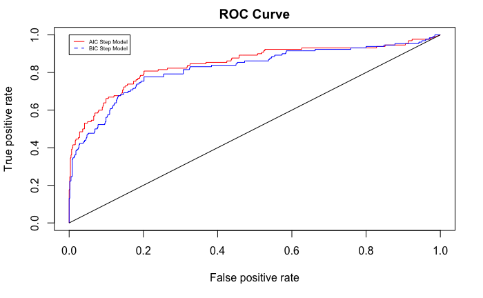

```r
lines(x = c(0,1), y = c(0,1), col="black")
legend(0, 1, legend=c("AIC Step Model", "BIC Step Model"),
       col=c("red", "blue"), lty=1:2, cex=0.5)
```

```r
##compute the AUC
aic_auc<-performance(aic_rates, measure = "auc")
aic_auc
```

```
An object of class "performance"
Slot "x.name":
[1] "None"

Slot "y.name":
[1] "Area under the ROC curve"

Slot "alpha.name":
[1] "none"

Slot "x.values":
list()

Slot "y.values":
[[1]]
[1] 0.8456834


Slot "alpha.values":
list()
```

```r
bic_auc<-performance(bic_rates, measure = "auc")
bic_auc
```

```
An object of class "performance"
Slot "x.name":
[1] "None"

Slot "y.name":
[1] "Area under the ROC curve"

Slot "alpha.name":
[1] "none"

Slot "x.values":
list()

Slot "y.values":
[[1]]
[1] 0.8217673


Slot "alpha.values":
list()
```

```r
##confusion matrix. Actual values in the rows, predicted classification in cols
table(test$Attrition, aic_preds>0.5)
```

```
      FALSE TRUE
  No    579   26
  Yes    61   69
```

```r
table(test$Attrition, bic_preds>0.5)
```

```
      FALSE TRUE
  No    580   25
  Yes    73   57
```

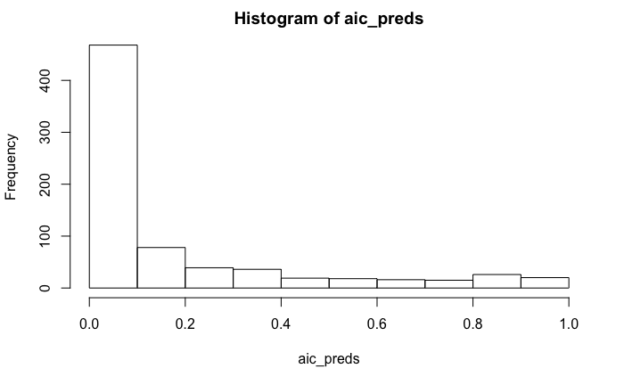

```r
hist(aic_preds)
```

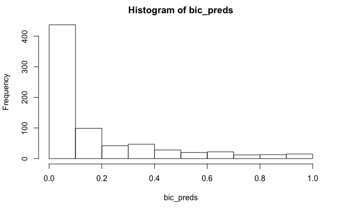

```r
hist(bic_preds)
```